# 消失的客户

———某移动通讯客户流失因素分析及建模

常佳奇-1910005

2022-02-27

## ${背景介绍}$

$\qquad$通信技术作为信息技术的组成部分，使人们逐渐走入了数字化时代。随着新技术的投入应用，通讯业也在不断进步和发展，使得人们传递信息的速度更快，能更方便的分享资源，极大便利了人们的生活。为了进一步提高服务质量，并扩大市场份额，通讯公司之间的竞争不断加剧。

$\qquad$通讯业刚兴起时，运营商不断推出新的服务模式和业务来吸引新客户，主要依靠客户数量不断增长来获取利润。然而随着近些年通讯行业逐渐成熟，通讯人口数已经逐渐趋于饱和状态。对公司而言，此时再继续拓展新客户，带来的利润较小。通讯企业要想长久发展，必须另辟蹊径。

$\qquad$ 根据美国贝恩公司的调查，在商业社会中5％的客户留存率增长意味着公司利润30％的增长，同时把产品卖给老客户的概率是卖给新客户的3倍。报告还指出，吸引新客户的成本是留住现有客户的6-7倍!从调查结果可以看出，提高老客户服务质量防止现有客户流失，对企业的长足发展有着至关重要的作用。然而从三大运营商的2020年度报表来看，在这一年里，中国移动、中国联通用户流失数分别为835.9万户，1266.4万户，唯有中国电信用户数保持了正增长。在用户流失问题十分严重情况下，为了能提前预防客户流失，针对性提出服务改进，建立一套系统的客户流失预警体系已是燃眉之急。

## 数据总览

| 变量类型 | 变量名 | 取值范围 | 备注 |
| --- | --- | --- | --- |
| 直观变量 | 在网时长 | 183.98 ~ 4479.63 |  |
|  | 当月花费 | -2.76 ~ 511.05 |  |
|  | 花费的变化 | -1 ~ 2.67 |  |
| 衍生变量 | 个体的度 | -0.37 ~ 303.98 |  |
|  | 联系强度 | -2.35 ~ 62.51 |  |
|  | 个体信息熵 | 0 ~ 5.35 |  |
|  | 个体度的变化 | -1 ~ 7.33 |  |
| 因变量 | 是否流失 | 0 、 1 | 1代表流失,0代表未流失 |

## 探索性数据分析

```r
> #读入数据,并加载需要准备的包
> data <- read.csv("data/sampledata.csv")
> attach(data)
> library(ggplot2)
> #library(plotly)
```

### $\bullet$ 探究直观变量（在网时长、当月花费、花费的变化）与客户流失的关系

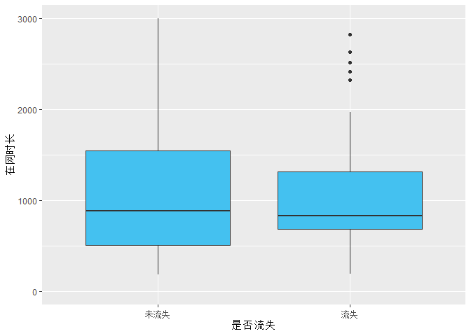

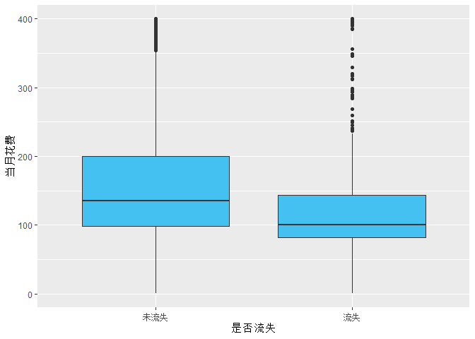

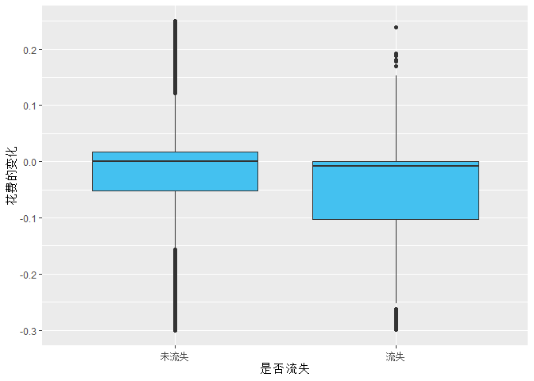

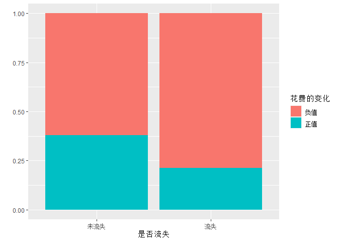

```r
> #col_names用来记录数据的列中文名，为后续用for循环绘图做准备
> #y_min、y_max分别记录绘图时纵坐标的最小值和最大值（设定绘图后y轴的显示范围）
> col_names <- c("编号","在网时长","当月花费","个体的度","联系强度","个体信息熵","花费的变化","个体度的变化")
> y_min <- c(0,0,0,0,1,-0.3,-1)
> y_max <- c(3000,400,150,20,5,0.25,1)
>
> #循环绘制箱线图（对于直观变量）
> for(i in c(2,3,7)){
+ p <- ggplot(data)+
+   geom_boxplot( aes( x = factor(churn), y = data[,i]) ,fill = "#44c1f0")+
+   labs(x = "是否流失",y = col_names[i])+
+   scale_x_discrete(labels=c("未流失","流失"))+
+   scale_y_continuous( limits = c(y_min[i-1] , y_max[i-1] ))
+
+ print(p)
+ }
>
> #考虑到花费的变化在正值和负值上有本质上的不同，将花费的变化这一数据重构进行绘制堆叠直方图，查看关系
> condition <- data$chgexpense>0
> ggplot(data, aes(x=factor(churn), fill=condition)) +
+     geom_bar(position="fill", stat="count")+
+   labs(x ="是否流失",y="",fill="花费的变化")+
+   scale_x_discrete(labels = c("未流失","流失"))+
+   scale_fill_discrete(labels = c("负值","正值"))
```

$\qquad$ 对上图，从总体来看，对于在网时长（左上图）这一指标，流失用户和非流失用户无明显差异，但流失用户的在网时长较为集中。对于当月花费（右上图）这一指标，流失用户明显较低且数据集中。而从花费的变化这一指标来看，流失客户也低于非流失用户的值，说明要流失的用户已经开始减少花费增量甚至出现削减花费的趋势。  
$\qquad$ 进一步考虑到花费的变化这一指标中正负值的意义差距明显，于是对将花费的变化分为了两类（正值和负值）进行绘图（左下图）。从图可以看出，相比于非流失用户，流失用户花费的变化为负值的比例更大，这也进一步提醒营业者，当用户花费比过去少时，就应考虑用户是否会流失问题。

### $\bullet$ 探究衍生变量（个体的度、联系强度、个体信息熵、个体度的变化）与客户流失之间的关系

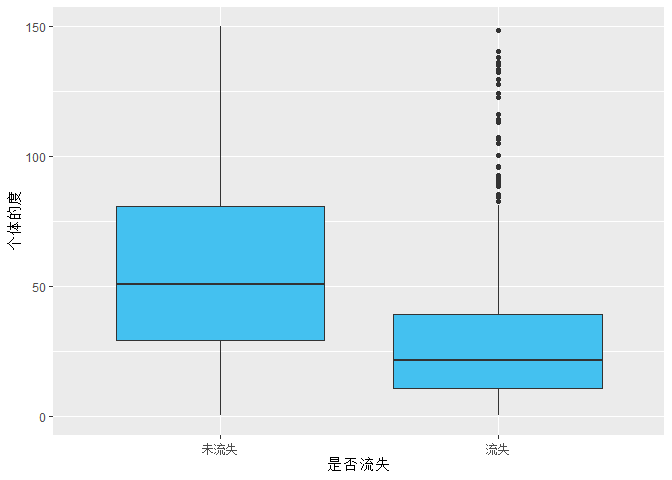

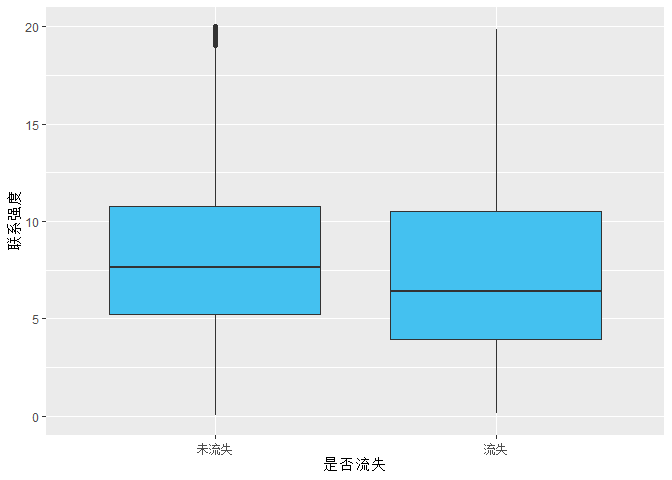

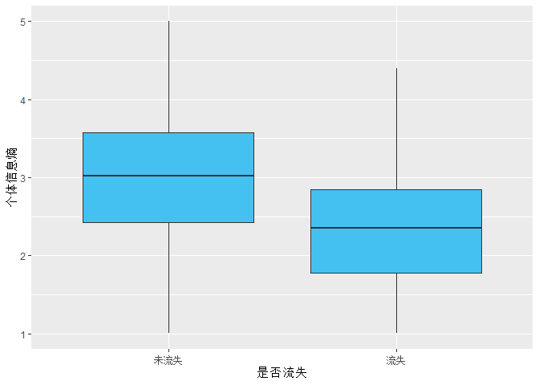

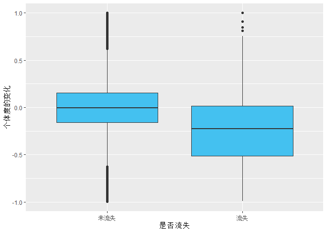

```r
> #col_names用来记录数据的列中文名，为后续用for循环绘图做准备
> #y_min、y_max分别记录绘图时纵坐标的最小值和最大值（设定绘图后y轴的显示范围）
>
> for(i in c(4,5,6,8)){
+ p <- ggplot(data)+
+   geom_boxplot( aes( x = factor(churn), y = data[,i]) ,fill = "#44c1f0")+
+   labs(x = "是否流失",y = col_names[i])+
+   scale_x_discrete(labels=c("未流失","流失"))+
+   scale_y_continuous( limits = c(y_min[i-1] , y_max[i-1] ))
+
+ print(p)
+ }
```

### $\bullet$ 检查数据是否存在多重共线性问题

```r
> #检验是否有多重共线性---特征根判别法(选取为数字类型的自变量)
> XX <- cor(data[,c(2:8)])
> kappa( XX, exact = T)
```

```
[1] 14.80545
```

$\qquad$ 采用特征根判别法，得到的条件数为14.8，<100，故不认为数据存在严重的多重共线性，也就是可以认为自变量之间是线性无关的。